# Practical Machine Learning: Prediction Assignment

Johan Vásquez Mazo

# Overview

# Data Tidying

The first step is downloading the two datasets linked in the assignment: `training.csv` and `testing.csv`. These datasets come from the paper Qualitative Activity Recognition of Weight Lifting Exercises[^1].

```r
# Download "training" dataset
if (!file.exists("training.csv")) {
    download.file(url = "https://d396qusza40orc.cloudfront.net/predmachlearn/pml-training.csv",
                  destfile = "training.csv")
}
# Download "testing" dataset
if (!file.exists("testing.csv")) {
    download.file(url = "https://d396qusza40orc.cloudfront.net/predmachlearn/pml-testing.csv",
                  destfile = "testing.csv")
}
# Files in directory
dir()
```

[output not shown]

The next step is reading both datasets. The `training.csv` file is read into a data frame named `training`, and the `testing.csv` file is read into a data frame named `testing`. By checking their dimensions using `dim`, it is seen that `training` has 19622 observations of 160 variables, and `testing` has 20 observations of 160 variables. Since the percentage of `testing` observations is very low (0.1%), the `training` dataset must be partitioned into actual training and testing datasets. Moreover, an out-of-sample error cannot be estimated using the `testing` dataset because the outcome variable (`classe`) is not present in it.

```r
# Read datasets
training <- read.csv("training.csv")
testing <- read.csv("testing.csv")
# Check dimensions
dim(training)
```

```
## [1] 19622   160
```

```r
dim(testing)
```

```
## [1]  20 160
```

```r
# "Testing" observations percentage
dim(testing)[1]/(dim(training)[1] + dim(testing)[1])*100
```

```
## [1] 0.1018226
```

After exploring the `training` dataset using the function `summary`, `str` and `View` in RStudio, it is seen that a lot of variables are mostly `NA`s, and some others are mostly empty characters, which is not reasonable since they should be numeric. Therefore, every variable that should be numeric is converted to such class. These are the 8th to 159th variables, which are mostly statistical measurements: average, standard deviation, variance, minimum, maximum, amplitude, skewness and kurtosis. It is also seen that the first 7 variables can be withdrawn, for they only serve to identify the measurements. Additionally, the last variable, `classe`, is converted into a factor, keeping in mind that it is the outcome to be predicted.

```r
# Convert non-numeric variables to numeric
for (i in 8:159) {
    training[ , i] <- as.numeric(training[ , i])
}
# Remove first 7 variables
training <- training[ , -(1:7)]
# Convert last variable to factor
training$classe <- as.factor(training$classe)
```

When coercing empty characters into numeric, the result is `NA`, so the following step is handling that large value of `NA`s. After calculating the total number of `NA`s for each variable, it is seen that the result is either 0, or greater than or equal to 19216; i.e., every variable either has no `NA`s or is mostly `NA`s. That being said, the next step is removing the mostly `NA` variables. This is performed by setting a threshold for the percentage of `NA` values equal to 10% for each variable.

```r
# Calculate total number of NAs for each variable
min(setdiff(sapply(training, function(x) {sum(is.na(x))}), 0))
```

```
## [1] 19216
```

```r
# Calculate which variables meet the NA percentage threshold
cols <- sapply(training, function(x) {mean(is.na(x)) <= 0.1})
```

The resulting data frame has 19622 observations of only 53 variables, and there is no need of imputing missing values since there are none.

```r
training <- training[ , cols]
dim(training)
```

```
## [1] 19622    53
```

# Exploratory Data Analyses

Now that the `training` dataset is tidy, it is partitioned into a `Train` data frame and a `Test` data frame, which are actual training and testing datasets in order to guarantee that cross-validation can be performed. The `Train` data frame contains 80% of the original observations, and the `Test` data frame contains the remaining 20%.

```r
suppressWarnings(suppressMessages(library(caret)))
set.seed(1404)
# Create subtraining and subtesting datasets
inTrain <- createDataPartition(training$classe, p = 0.8, list = FALSE)
Train <- training[inTrain, ]
Test <- training[-inTrain, ]
# Check dimensions
dim(Train)
```

```
## [1] 15699    53
```

```r
dim(Test)
```

```
## [1] 3923   53
```

In order to further explore the data, the correlation matrix is calculated to get a grasp of whether some variables may be good predictors or not. The diagonal of this matrix is then set to zero to know which variables are the most correlated.

```r
# Calculate correlation matrix
corMatrix <- cor(Train[ , -53])
# Set diagonal values to 0
diag(corMatrix) <- 0
```

The plot of the modified correlation matrix is shown below, where red squares correspond to negatively correlated variables, and dark turquoise squares correspond to positively correlated variables. The smaller and whiter the square, the lower the magnitude of the correlation.

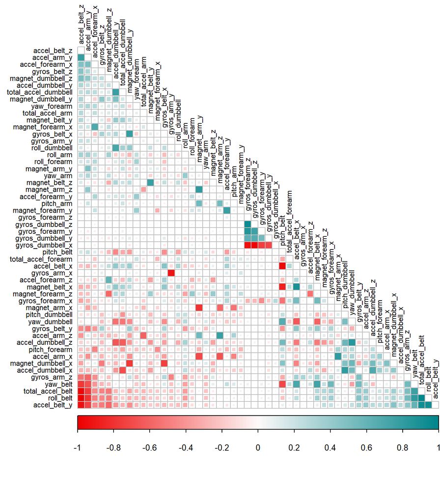

```r
library(corrplot)
col1 <- colorRampPalette(c("red2", "snow1", "turquoise4"))
corrplot(corMatrix, order = "FPC", method = "square", type = "lower", tl.col = "black",
         tl.cex = 0.7, col = col1(200))
```

From either the correlation matrix or its plot, it is found that the most negatively correlated variables are `accel_belt_z` and `roll_belt`, and the most positively correlated variables are `total_accel_belt` and `roll_belt`. Since the most correlated pairs of variables include `roll_belt` as one of them, this variable is excluded to examine other pairs of highly correlated variables. After excluding `roll_belt`, it is found that the most negatively correlated variables are `gyros_dumbbell_z` and `gyros_dumbbell_x`, and the most positively correlated variables are `gyros_forearm_z` and `gyros_dumbbell_z`. The following plot shows the scatterplots of the previous four pairs of variables including the `classe` outcome, so as to help identify if there are patterns between the variables and the outcome.

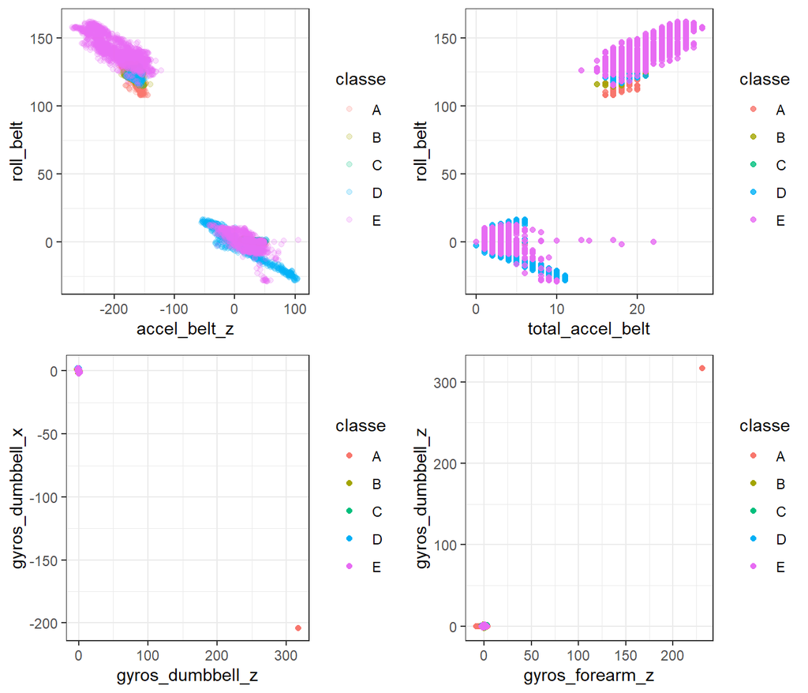

```r
library(ggplot2)
library(gridExtra)
# Including roll_belt
min1 <- ggplot(aes(x = accel_belt_z, y = roll_belt, col = classe), data = Train) +
    geom_point(alpha = 0.2) + theme_bw()
max1 <- ggplot(aes(x = total_accel_belt, y = roll_belt, col = classe), data = Train) +
    geom_point(alpha = 0.8) + theme_bw()
# Excluding roll_belt
min2 <- ggplot(aes(x = gyros_dumbbell_z, y = gyros_dumbbell_x, col = classe), data = Train) +
    geom_point(alpha = 1) + theme_bw()
max2 <- ggplot(aes(x = gyros_forearm_z, y = gyros_dumbbell_z, col = classe), data = Train) +
    geom_point(alpha = 1) + theme_bw()
# Arranged plot
grid.arrange(min1, max1, min2, max2, nrow = 2, ncol = 2)
```

Some interesting information can be drawn from the previous scatterplots. First, there does not appear to be an obvious pattern between the outcome and the variables `accel_belt_z`, `total_accel_belt` and `roll_belt`, so there is no hint as to what variables to choose as predictors based on correlation. However, there is a more intriguing fact about the plots, specifically the scatterplots of `gyros_dumbbell_z`, `gyros_dumbbell_x` and `gyros_forearm_z`. All the points in these scatterplots, but one, are relatively close; and the values for each variable of this outlier are far away from the rest of the data. This is a perfect example of the effect that one high leverage point can have on statistics such as mean and correlation. It cannot be determined if that outlier corresponds to faulty or genuine data; but, given that it is only 1 of 15699 observations and its values are extremely distant from all the other data, removing it seems reasonable.

# Prediction

From the exploratory analyses, it was concluded that, for this dataset, correlation does not seem to be a good criterion of which variables to choose as predictors for the outcome `classe`. Since the outcome is a factor variable, models such as decision trees (CART), random forests (RF), gradient boosting (or generalized boosted models, GBM), and linear discriminant analysis (LDA) are good options. These four models will then be chosen to perform the predictions. As for cross-validation, k-fold cross-validation seems to be appropriate considering the size of the data, for leave-one-out cross-validation would require too much computation power. The chosen number of folds is 5, meaning that 20% of the `Train` data is used to cross-validate the model, and this is performed five times.

```r
set.seed(1404)
## Set k equal to 5 for k-folds cross-validation
train.control <- trainControl(method = "cv", number = 5)
## Train the models
modelFitCART <- train(classe ~ ., data = Train, method = "rpart", trControl = train.control)
modelFitRF <- train(classe ~ ., data = Train, method = "rf", trControl = train.control)
modelFitGBM <- train(classe ~ ., data = Train, method = "gbm", trControl = train.control, verbose = FALSE)
modelFitLDA <- train(classe ~ ., data = Train, method = "lda", trControl = train.control)
```

Now that the models are trained, it is time to evaluate their performance on the `Train` and `Test` datasets in order to calculate an in-sample error and, more importantly, estimate an out-of-sample error, respectively.

```r
# Predictions on the Train dataset
trainCART <- predict(modelFitCART, Train)
trainRF <- predict(modelFitRF, Train)
trainGBM <- predict(modelFitGBM, Train)
trainLDA  <- predict(modelFitLDA, Train)
# Calculated in-sample accuracies
inCART <- confusionMatrix(trainCART, Train$classe)$overall[1]
inRF <- confusionMatrix(trainRF, Train$classe)$overall[1]
inGBM <- confusionMatrix(trainGBM, Train$classe)$overall[1]
inLDA <- confusionMatrix(trainLDA, Train$classe)$overall[1]
# Data frame with in-sample-errors
inAccuracy <- data.frame(Model = c("CART", "RF", "GBM", "LDA"),
                         In.Sample.Accuracy = c(inCART, inRF, inGBM, inLDA))
inAccuracy$In.Sample.Error <- 1 - inAccuracy$In.Sample.Accuracy
inAccuracy
```

```
##   Model In.Sample.Accuracy In.Sample.Error
## 1  CART          0.4960826      0.50391745
## 2    RF          1.0000000      0.00000000
## 3   GBM          0.9742659      0.02573412
## 4   LDA          0.7071788      0.29282120
```

From the shown results, it is seen that the random forest model yields an in-sample accuracy of 1, having basically an in-sample error equal to 0, which means it is a perfect prediction model for the `Train` dataset; however, this may be due to overfitting, so this must be tested using the `Test` dataset. This seems reasonable since it was the model that took the longest to complete its training. On the other hand, the decision tree model was the worst performing, having an in-sample accuracy of 0.4961 and an in-sample error of 0.5039. The gradient boosting model also performed greatly, followed by the linear discriminant analysis model.

```r
# Predictions on the Test dataset
testCART <- predict(modelFitCART, Test)
testRF <- predict(modelFitRF, Test)
testGBM <- predict(modelFitGBM, Test)
testLDA  <- predict(modelFitLDA, Test)
# Estimated out-of-sample accuracies
outCART <- confusionMatrix(testCART, Test$classe)$overall[1]
outRF <- confusionMatrix(testRF, Test$classe)$overall[1]
outGBM <- confusionMatrix(testGBM, Test$classe)$overall[1]
outLDA <- confusionMatrix(testLDA, Test$classe)$overall[1]
# Data frame with out-of-sample errors
outAccuracy <- data.frame(Model = c("CART", "RF", "GBM", "LDA"),
           Out.of.Sample.Accuracy = c(outCART, outRF, outGBM, outLDA))
outAccuracy$Out.of.Sample.Error <- 1 - outAccuracy$Out.of.Sample.Accuracy
outAccuracy
```

```
##   Model Out.of.Sample.Accuracy Out.of.Sample.Error
## 1  CART              0.4947744         0.505225593
## 2    RF              0.9938822         0.006117767
## 3   GBM              0.9592149         0.040785113
## 4   LDA              0.6966607         0.303339281
```

## Prediction

Considering that the random forest model was the best-performing, it is used on the original `testing` dataset to predict the outcome `classe`. It is predicted that 7 out of the 20 measurements correspond to subjects who performed the weight lifting exercise correctly, as it is shown below.

```r
pred <- predict(modelFitRF, testing)
data.frame(ID = testing$problem_id, Predicted.Class = pred)
```

```
##    ID Predicted.Class
## 1   1               B
## 2   2               A
## 3   3               B
## 4   4               A
## 5   5               A
## 6   6               E
## 7   7               D
## 8   8               B
## 9   9               A
## 10 10               A
## 11 11               B
## 12 12               C
## 13 13               B
## 14 14               A
## 15 15               E
## 16 16               E
## 17 17               A
## 18 18               B
## 19 19               B
## 20 20               B
```

# Appendix

## Appendix A: Extra Code

```r
## Calculate which variables are the most correlated
# Most negatively correlated
corMatrix[which.min(corMatrix)]
```

```
## [1] -0.9920583
```

```r
indexmin <- which.min(corMatrix)
rowmin <- rownames(corMatrix)[ifelse((indexmin %% 52) != 0, indexmin %% 52, 52)]
colmin <- colnames(corMatrix)[ceiling(indexmin/52)]
c(rowmin, colmin)
```

```
## [1] "accel_belt_z" "roll_belt"
```

```r
cor(Train$accel_belt_z, Train$roll_belt)
```

```
## [1] -0.9920583
```

```r
# Most positively correlated
corMatrix[which.max(corMatrix)]
```

```
## [1] 0.9807965
```

```r
indexmax <- which.max(corMatrix)
rowmax <- rownames(corMatrix)[ifelse((indexmax %% 52) != 0, indexmax %% 52, 52)]
colmax <- colnames(corMatrix)[ceiling(indexmax/52)]
c(rowmax, colmax)
```

```
## [1] "total_accel_belt" "roll_belt"
```

```r
cor(Train$total_accel_belt, Train$roll_belt)
```

```
## [1] 0.9807965
```

```r
## Calculate which variables, different than roll_belt, are the most correlated
corMatrix2 <- corMatrix[-1, -1]
# Most negatively correlated
corMatrix2[which.min(corMatrix2)]
```

```
## [1] -0.9830481
```

```r
indexmin2 <- which.min(corMatrix2)
rowmin2 <- rownames(corMatrix2)[ifelse((indexmin2 %% 51) != 0, indexmin2 %% 51, 51)]
colmin2 <- colnames(corMatrix2)[ceiling(indexmin2/51)]
c(rowmin2, colmin2)
```

```
## [1] "gyros_dumbbell_z" "gyros_dumbbell_x"
```

```r
cor(Train$gyros_dumbbell_z, Train$gyros_dumbbell_x)
```

```
## [1] -0.9830481
```

```r
# Most positively correlated
corMatrix2[which.max(corMatrix2)]
```

```
## [1] 0.9455076
```

```r
indexmax2 <- which.max(corMatrix2)
rowmax2 <- rownames(corMatrix2)[ifelse((indexmax2 %% 51) != 0, indexmax2 %% 51, 51)]
colmax2 <- colnames(corMatrix2)[ceiling(indexmax2/51)]
c(rowmax2, colmax2)
```

```
## [1] "gyros_forearm_z"  "gyros_dumbbell_z"
```

```r
cor(Train$gyros_forearm_z, Train$gyros_dumbbell_z)
```

```
## [1] 0.9455076
```

```r
## Correlation of the second most correlated variables after removing outliers
Train2 <- Train[-which.max(Train$gyros_dumbbell_z), ]
# Second most negatively correlated
cor(Train2$gyros_dumbbell_z, Train2$gyros_dumbbell_x)
```

```
## [1] -0.6157888
```

```r
# Second most positively correlated
cor(Train2$gyros_forearm_z, Train2$gyros_dumbbell_z)
```

```
## [1] 0.05747839
```

## Appendix B: Extra Plot

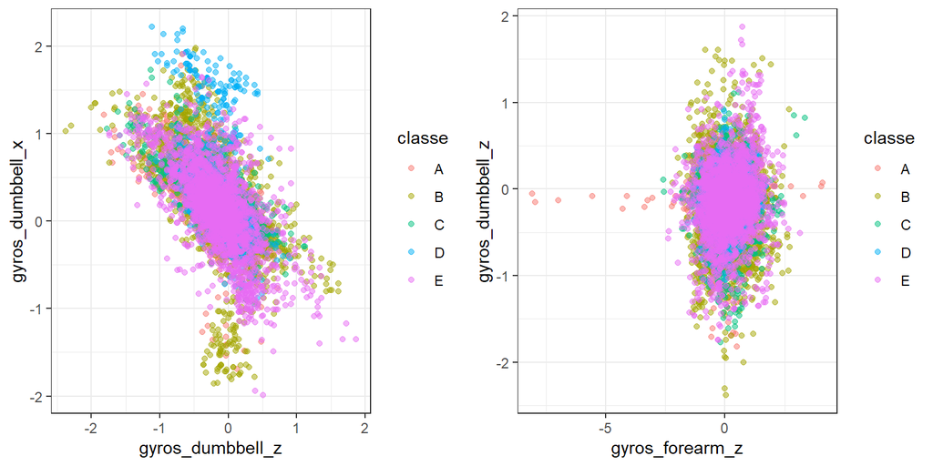

```r
# Excluding roll_belt and outliers
min2no <- ggplot(aes(x = gyros_dumbbell_z, y = gyros_dumbbell_x, col = classe), data = Train2) +
    geom_point(alpha = 0.5) + theme_bw()
max2no <- ggplot(aes(x = gyros_forearm_z, y = gyros_dumbbell_z, col = classe), data = Train2) +
    geom_point(alpha = 0.5) + theme_bw()
# Arranged plot
grid.arrange(min2no, max2no, nrow = 1, ncol = 2)
```

# References

[^1]: Velloso, E.; Bulling, A.; Gellersen, H.; Ugulino, W.; Fuks, H. Qualitative Activity Recognition of Weight Lifting Exercises. Proceedings of 4th International Conference in Cooperation with SIGCHI (Augmented Human ’13) . Stuttgart, Germany: ACM SIGCHI, 2013. http://groupware.les.inf.puc-rio.br/har%7D#ixzz6VCw3JT15